# R Notebook

Logistic Regression

```r
credit<-read.csv('C:\\Users\\Gaya\\Desktop\\R\\EDX_Scripts\\Principles-of-Machine-Learning-R-master\\Module4\\German_Credit_Preped.csv',stringsAsFactors = F)
str(credit)
```

```
'data.frame':   1000 obs. of  22 variables:
 $ Customer_ID             : int  1122334 6156361 2051359 8740590 3924540 3115687 8251714 2272783 1865292 8369450 ...
 $ checking_account_status : chr  "< 0 DM" "0 - 200 DM" "none" "< 0 DM" ...
 $ loan_duration_mo        : int  6 48 12 42 24 36 24 36 12 30 ...
 $ credit_history          : chr  "critical account - other non-bank loans" "current loans paid" "critical account - other non-bank loans" "current loans paid" ...
 $ purpose                 : chr  "radio/television" "radio/television" "education" "furniture/equipment" ...
 $ loan_amount             : int  1169 5951 2096 7882 4870 9055 2835 6948 3059 5234 ...
 $ savings_account_balance : chr  "unknown/none" "< 100 DM" "< 100 DM" "< 100 DM" ...
 $ time_employed_yrs       : chr  ">= 7 years" "1 - 4 years" "4 - 7 years" "4 - 7 years" ...
 $ payment_pcnt_income     : int  4 2 2 2 3 2 3 2 2 4 ...
 $ gender_status           : chr  "male-single" "female-divorced/separated/married" "male-single" "male-single" ...
 $ other_signators         : chr  "none" "none" "none" "guarantor" ...
 $ time_in_residence       : int  4 2 3 4 4 4 4 2 4 2 ...
 $ property                : chr  "real estate" "real estate" "real estate" "building society savings/life insurance" ...
 $ age_yrs                 : int  67 22 49 45 53 35 53 35 61 28 ...
 $ other_credit_outstanding: chr  "none" "none" "none" "none" ...
 $ home_ownership          : chr  "own" "own" "own" "for free" ...
 $ number_loans            : int  2 1 1 1 2 1 1 1 1 2 ...
 $ job_category            : chr  "skilled" "skilled" "unskilled-resident" "skilled" ...
 $ dependents              : int  1 1 2 2 2 2 1 1 1 1 ...
 $ telephone               : chr  "yes" "none" "none" "none" ...
 $ foreign_worker          : chr  "yes" "yes" "yes" "yes" ...
 $ bad_credit              : int  0 1 0 0 1 0 0 0 0 1 ...
```

```r
library(caret)
library(dplyr)
library(MASS)
library(Metrics)
```

IMPORTANT before modeling anything in classification we need to look at class distribution in our target variable

Let’s make factorize bad credits feature for avoiding future problems

```r
credit$bad_credit<-factor(credit$bad_credit, levels = c(0, 1), labels = c('No','Yes'))
levels(credit$bad_credit)
```

```
[1] "No"  "Yes"
```

```r
as.numeric(credit$bad_credit)
```

[output not shown]

```r
str(credit$bad_credit)
```

```
 Factor w/ 2 levels "No","Yes": 1 2 1 1 2 1 1 1 1 2 ...
```

```r
table(credit$bad_credit)
```

```
 No Yes
700 300
```

Not good there are more than twice ‘good’ bank customers as we have ‘bad’ customer (i.e. bad means defaulted and from bank perspective they are ‘bad’ ).. This is really nasty situation as we shoud predict more precisely bad customers as risks and costs asssociated with a bad customers are higher compared to leaving oner good customer.In practice we will use imputation and other balancing techniques…. or another approach may be adjusting model at the ned towards precisely predicting exactly this class!!!! We will use second approach in this case!!

```r
ind<-createDataPartition(credit$bad_credit,p=0.70,list = F)
credit1<-credit%>%
  dplyr::select(-Customer_ID)
dim(credit1)
```

```
[1] 1000   21
```

```r
credit_train<-credit1[ind,]
credit_test<-credit1[-ind,]
colnames(credit_train)
```

```
 [1] "checking_account_status"  "loan_duration_mo"         "credit_history"
 [4] "purpose"                  "loan_amount"              "savings_account_balance"
 [7] "time_employed_yrs"        "payment_pcnt_income"      "gender_status"
[10] "other_signators"          "time_in_residence"        "property"
[13] "age_yrs"                  "other_credit_outstanding" "home_ownership"
[16] "number_loans"             "job_category"             "dependents"
[19] "telephone"                "foreign_worker"           "bad_credit"
```

```r
mod1<-glm(bad_credit~.,data=credit_train,family = 'binomial')
mod2<-stepAIC(mod1,method='both')
```

```
Start:  AIC=699.76
bad_credit ~ checking_account_status + loan_duration_mo + credit_history +
    purpose + loan_amount + savings_account_balance + time_employed_yrs +
    payment_pcnt_income + gender_status + other_signators + time_in_residence +
    property + age_yrs + other_credit_outstanding + home_ownership +
    number_loans + job_category + dependents + telephone + foreign_worker

                           Df Deviance    AIC
- job_category              3   602.86 694.86
- property                  3   604.76 696.76
- time_employed_yrs         4   606.85 696.85
- home_ownership            2   602.98 696.98
- time_in_residence         1   601.79 697.79
- age_yrs                   1   601.83 697.83
- dependents                1   602.59 698.59
- telephone                 1   603.39 699.39
<none>                          601.76 699.76
- number_loans              1   603.88 699.88
- foreign_worker            1   604.79 700.79
- other_credit_outstanding  2   608.70 702.70
- other_signators           2   608.94 702.94
- loan_amount               1   607.84 703.84
- gender_status             3   614.22 706.22
- loan_duration_mo          1   610.78 706.78
- payment_pcnt_income       1   615.12 711.12
- savings_account_balance   4   621.91 711.91
- credit_history            4   622.03 712.03
- purpose                   9   634.15 714.15
- checking_account_status   3   646.70 738.70

Step:  AIC=694.86
bad_credit ~ checking_account_status + loan_duration_mo + credit_history +
    purpose + loan_amount + savings_account_balance + time_employed_yrs +
    payment_pcnt_income + gender_status + other_signators + time_in_residence +
    property + age_yrs + other_credit_outstanding + home_ownership +
    number_loans + dependents + telephone + foreign_worker

                           Df Deviance    AIC
- property                  3   605.72 691.72
- time_employed_yrs         4   607.83 691.83
```

[output cut: 174 more lines]

```

                           Df Deviance    AIC
<none>                          614.84 680.84
- foreign_worker            1   617.99 681.99
- telephone                 1   618.34 682.34
- loan_amount               1   621.03 685.03
- other_signators           2   623.57 685.57
- other_credit_outstanding  2   623.65 685.65
- loan_duration_mo          1   624.62 688.62
- gender_status             3   629.27 689.27
- payment_pcnt_income       1   627.43 691.43
- savings_account_balance   4   636.10 694.10
- credit_history            4   636.20 694.20
- purpose                   9   651.69 699.69
- checking_account_status   3   664.17 724.17
```

```r
mod2$anova
```

```
Stepwise Model Path
Analysis of Deviance Table

Initial Model:
bad_credit ~ checking_account_status + loan_duration_mo + credit_history +
    purpose + loan_amount + savings_account_balance + time_employed_yrs +
    payment_pcnt_income + gender_status + other_signators + time_in_residence +
    property + age_yrs + other_credit_outstanding + home_ownership +
    number_loans + job_category + dependents + telephone + foreign_worker

Final Model:
bad_credit ~ checking_account_status + loan_duration_mo + credit_history +
    purpose + loan_amount + savings_account_balance + payment_pcnt_income +
    gender_status + other_signators + other_credit_outstanding +
    telephone + foreign_worker

                 Step Df   Deviance Resid. Df Resid. Dev      AIC
1                                         651   601.7604 699.7604
2      - job_category  3 1.10238155       654   602.8627 694.8627
3          - property  3 2.85233443       657   605.7151 691.7151
4 - time_employed_yrs  4 4.85737821       661   610.5725 688.5725
5    - home_ownership  2 1.19555217       663   611.7680 685.7680
6 - time_in_residence  1 0.02094329       664   611.7890 683.7890
7           - age_yrs  1 0.25081012       665   612.0398 682.0398
8        - dependents  1 0.94602597       666   612.9858 680.9858
9      - number_loans  1 1.85459758       667   614.8404 680.8404
```

```r
summary(mod2)
```

```
Call:
glm(formula = bad_credit ~ checking_account_status + loan_duration_mo +
    credit_history + purpose + loan_amount + savings_account_balance +
    payment_pcnt_income + gender_status + other_signators + other_credit_outstanding +
    telephone + foreign_worker, family = "binomial", data = credit_train)

Deviance Residuals:
    Min       1Q   Median       3Q      Max
-2.3688  -0.6880  -0.3468   0.7176   2.9263

Coefficients:
                                                        Estimate Std. Error z value Pr(>|z|)
(Intercept)                                           -6.134e-01  1.038e+00  -0.591 0.554544
checking_account_status> 200 DM or salary assignment  -6.854e-01  4.505e-01  -1.521 0.128174
checking_account_status0 - 200 DM                     -3.753e-01  2.603e-01  -1.441 0.149445
checking_account_statusnone                           -1.780e+00  2.804e-01  -6.346 2.21e-10 ***
loan_duration_mo                                       3.495e-02  1.120e-02   3.120 0.001808 **
credit_historycritical account - other non-bank loans -1.568e+00  4.666e-01  -3.360 0.000778 ***
credit_historycurrent loans paid                      -8.546e-01  4.380e-01  -1.951 0.051007 .
credit_historyno credit - paid                         1.757e-01  6.193e-01   0.284 0.776583
credit_historypast payment delays                     -6.873e-01  5.223e-01  -1.316 0.188268
purposecar (new)                                       1.102e+00  4.210e-01   2.618 0.008844 **
purposecar (used)                                     -5.534e-01  5.334e-01  -1.038 0.299447
purposedomestic appliances                             1.525e+00  9.181e-01   1.661 0.096752 .
purposeeducation                                       1.507e+00  5.543e-01   2.719 0.006540 **
purposefurniture/equipment                             4.489e-01  4.275e-01   1.050 0.293673
purposeother                                           7.911e-02  8.446e-01   0.094 0.925377
purposeradio/television                               -2.241e-01  4.235e-01  -0.529 0.596756
purposerepairs                                         9.917e-01  7.128e-01   1.391 0.164121
purposeretraining                                      2.215e-01  1.357e+00   0.163 0.870324
loan_amount                                            1.238e-04  5.031e-05   2.460 0.013888 *
savings_account_balance>= 1000 DM                     -1.601e+00  6.434e-01  -2.489 0.012827 *
savings_account_balance100 - 500 DM                   -4.962e-01  3.493e-01  -1.420 0.155467
savings_account_balance500 - 1000 DM                  -4.198e-01  4.787e-01  -0.877 0.380451
savings_account_balanceunknown/none                   -1.173e+00  3.112e-01  -3.767 0.000165 ***
payment_pcnt_income                                    3.563e-01  1.026e-01   3.473 0.000514 ***
gender_statusmale-divorced/separated                   2.720e-01  4.338e-01   0.627 0.530620
gender_statusmale-married/widowed                     -4.867e-02  3.841e-01  -0.127 0.899180
gender_statusmale-single                              -7.670e-01  2.387e-01  -3.214 0.001310 **
other_signatorsguarantor                              -1.926e+00  6.703e-01  -2.873 0.004068 **
other_signatorsnone                                   -9.480e-01  4.855e-01  -1.953 0.050865 .
other_credit_outstandingnone                          -7.584e-01  2.831e-01  -2.678 0.007396 **
other_credit_outstandingstores                         7.626e-03  4.700e-01   0.016 0.987054
telephoneyes                                          -4.220e-01  2.275e-01  -1.855 0.063528 .
foreign_workeryes                                      1.141e+00  6.887e-01   1.657 0.097575 .
---
Signif. codes:  0 ‘***’ 0.001 ‘**’ 0.01 ‘*’ 0.05 ‘.’ 0.1 ‘ ’ 1

(Dispersion parameter for binomial family taken to be 1)

    Null deviance: 855.21  on 699  degrees of freedom
Residual deviance: 614.84  on 667  degrees of freedom
AIC: 680.84

Number of Fisher Scoring iterations: 5
```

Let’s analyse the model that we got

```r
unique(credit_train$payment_pcnt_income)
```

```
[1] 4 2 3 1
```

```r
colnames(credit_train)
```

```
 [1] "checking_account_status"  "loan_duration_mo"         "credit_history"
 [4] "purpose"                  "loan_amount"              "savings_account_balance"
 [7] "time_employed_yrs"        "payment_pcnt_income"      "gender_status"
[10] "other_signators"          "time_in_residence"        "property"
[13] "age_yrs"                  "other_credit_outstanding" "home_ownership"
[16] "number_loans"             "job_category"             "dependents"
[19] "telephone"                "foreign_worker"           "bad_credit"
```

```r
mod3<-glm(bad_credit~checking_account_status+loan_duration_mo+credit_history+purpose+loan_amount+
            other_signators+number_loans+gender_status,data=credit_train,family='binomial')
summary(mod3)
```

```
Call:
glm(formula = bad_credit ~ checking_account_status + loan_duration_mo +
    credit_history + purpose + loan_amount + other_signators +
    number_loans + gender_status, family = "binomial", data = credit_train)

Deviance Residuals:
    Min       1Q   Median       3Q      Max
-2.4669  -0.7257  -0.4133   0.7945   2.7041

Coefficients:
                                                        Estimate Std. Error z value Pr(>|z|)
(Intercept)                                            3.808e-01  7.997e-01   0.476  0.63398
checking_account_status> 200 DM or salary assignment  -8.033e-01  4.253e-01  -1.889  0.05895 .
checking_account_status0 - 200 DM                     -5.085e-01  2.427e-01  -2.095  0.03617 *
checking_account_statusnone                           -1.858e+00  2.609e-01  -7.121 1.07e-12 ***
loan_duration_mo                                       4.287e-02  1.039e-02   4.127 3.68e-05 ***
credit_historycritical account - other non-bank loans -1.913e+00  4.617e-01  -4.143 3.43e-05 ***
credit_historycurrent loans paid                      -9.821e-01  4.053e-01  -2.423  0.01539 *
credit_historyno credit - paid                        -5.742e-02  5.929e-01  -0.097  0.92284
credit_historypast payment delays                     -1.018e+00  5.141e-01  -1.981  0.04765 *
purposecar (new)                                       8.612e-01  3.914e-01   2.200  0.02780 *
purposecar (used)                                     -6.955e-01  4.999e-01  -1.391  0.16419
purposedomestic appliances                             1.289e+00  8.728e-01   1.477  0.13959
purposeeducation                                       1.381e+00  5.301e-01   2.606  0.00917 **
purposefurniture/equipment                             4.514e-01  4.043e-01   1.116  0.26422
purposeother                                           7.676e-02  8.318e-01   0.092  0.92648
purposeradio/television                               -1.444e-01  3.980e-01  -0.363  0.71674
purposerepairs                                         9.470e-01  6.930e-01   1.367  0.17176
purposeretraining                                      3.673e-02  1.212e+00   0.030  0.97581
loan_amount                                            3.587e-05  4.316e-05   0.831  0.40590
other_signatorsguarantor                              -1.759e+00  6.512e-01  -2.701  0.00692 **
other_signatorsnone                                   -9.498e-01  4.737e-01  -2.005  0.04495 *
number_loans                                           3.468e-01  2.113e-01   1.641  0.10073
gender_statusmale-divorced/separated                   2.109e-01  4.081e-01   0.517  0.60526
gender_statusmale-married/widowed                      9.214e-02  3.700e-01   0.249  0.80333
gender_statusmale-single                              -5.807e-01  2.251e-01  -2.579  0.00990 **
---
Signif. codes:  0 ‘***’ 0.001 ‘**’ 0.01 ‘*’ 0.05 ‘.’ 0.1 ‘ ’ 1

(Dispersion parameter for binomial family taken to be 1)

    Null deviance: 855.21  on 699  degrees of freedom
Residual deviance: 658.34  on 675  degrees of freedom
AIC: 708.34

Number of Fisher Scoring iterations: 5
```

```r
train_pred<-predict(mod3,newdata = credit_train,type='response')
train_pred<-ifelse(train_pred>0.5,1,0)
table(train_pred,credit_train$bad_credit)
```

```
train_pred  No Yes
         0 443  97
         1  47 113
```

```r
table(train_pred)
```

```
train_pred
  0   1
540 160
```

```r
train_pred<-factor(train_pred, levels = c(0, 1), labels = c('No','Yes'))
levels(train_pred)
```

```
[1] "No"  "Yes"
```

```r
as.numeric(train_pred)
```

[output not shown]

```r
str(train_pred)
```

```
 Factor w/ 2 levels "No","Yes": 1 2 1 2 1 1 1 1 2 1 ...
 - attr(*, "names")= chr [1:700] "1" "2" "3" "5" ...
```

```r
accuracy(actual = credit_train$bad_credit,predicted = train_pred)
```

```
[1] 0.7942857
```

```r
confusionMatrix(train_pred,credit_train$bad_credit,positive = 'Yes')
```

```
Confusion Matrix and Statistics

          Reference
Prediction  No Yes
       No  443  97
       Yes  47 113

               Accuracy : 0.7943
                 95% CI : (0.7624, 0.8237)
    No Information Rate : 0.7
    P-Value [Acc > NIR] : 1.116e-08

                  Kappa : 0.4745
 Mcnemar's Test P-Value : 4.439e-05

            Sensitivity : 0.5381
            Specificity : 0.9041
         Pos Pred Value : 0.7062
         Neg Pred Value : 0.8204
             Prevalence : 0.3000
         Detection Rate : 0.1614
   Detection Prevalence : 0.2286
      Balanced Accuracy : 0.7211

       'Positive' Class : Yes
```

```r
credit_train<-credit1[ind,]
credit_test<-credit1[-ind,]
colnames(credit_train)
```

```
 [1] "checking_account_status"  "loan_duration_mo"         "credit_history"
 [4] "purpose"                  "loan_amount"              "savings_account_balance"
 [7] "time_employed_yrs"        "payment_pcnt_income"      "gender_status"
[10] "other_signators"          "time_in_residence"        "property"
[13] "age_yrs"                  "other_credit_outstanding" "home_ownership"
[16] "number_loans"             "job_category"             "dependents"
[19] "telephone"                "foreign_worker"           "bad_credit"
```

```r
mod1<-glm(bad_credit~.,data=credit_train,family = 'binomial')
mod2<-stepAIC(mod1,method='both')
```

```
Start:  AIC=699.76
bad_credit ~ checking_account_status + loan_duration_mo + credit_history +
    purpose + loan_amount + savings_account_balance + time_employed_yrs +
    payment_pcnt_income + gender_status + other_signators + time_in_residence +
    property + age_yrs + other_credit_outstanding + home_ownership +
    number_loans + job_category + dependents + telephone + foreign_worker

                           Df Deviance    AIC
- job_category              3   602.86 694.86
- property                  3   604.76 696.76
- time_employed_yrs         4   606.85 696.85
- home_ownership            2   602.98 696.98
- time_in_residence         1   601.79 697.79
- age_yrs                   1   601.83 697.83
- dependents                1   602.59 698.59
- telephone                 1   603.39 699.39
<none>                          601.76 699.76
- number_loans              1   603.88 699.88
- foreign_worker            1   604.79 700.79
- other_credit_outstanding  2   608.70 702.70
- other_signators           2   608.94 702.94
- loan_amount               1   607.84 703.84
- gender_status             3   614.22 706.22
- loan_duration_mo          1   610.78 706.78
- payment_pcnt_income       1   615.12 711.12
- savings_account_balance   4   621.91 711.91
- credit_history            4   622.03 712.03
- purpose                   9   634.15 714.15
- checking_account_status   3   646.70 738.70

Step:  AIC=694.86
bad_credit ~ checking_account_status + loan_duration_mo + credit_history +
    purpose + loan_amount + savings_account_balance + time_employed_yrs +
    payment_pcnt_income + gender_status + other_signators + time_in_residence +
    property + age_yrs + other_credit_outstanding + home_ownership +
    number_loans + dependents + telephone + foreign_worker

                           Df Deviance    AIC
- property                  3   605.72 691.72
- time_employed_yrs         4   607.83 691.83
```

[output cut: 174 more lines]

```

                           Df Deviance    AIC
<none>                          614.84 680.84
- foreign_worker            1   617.99 681.99
- telephone                 1   618.34 682.34
- loan_amount               1   621.03 685.03
- other_signators           2   623.57 685.57
- other_credit_outstanding  2   623.65 685.65
- loan_duration_mo          1   624.62 688.62
- gender_status             3   629.27 689.27
- payment_pcnt_income       1   627.43 691.43
- savings_account_balance   4   636.10 694.10
- credit_history            4   636.20 694.20
- purpose                   9   651.69 699.69
- checking_account_status   3   664.17 724.17
```

```r
mod2$anova
```

```
Stepwise Model Path
Analysis of Deviance Table

Initial Model:
bad_credit ~ checking_account_status + loan_duration_mo + credit_history +
    purpose + loan_amount + savings_account_balance + time_employed_yrs +
    payment_pcnt_income + gender_status + other_signators + time_in_residence +
    property + age_yrs + other_credit_outstanding + home_ownership +
    number_loans + job_category + dependents + telephone + foreign_worker

Final Model:
bad_credit ~ checking_account_status + loan_duration_mo + credit_history +
    purpose + loan_amount + savings_account_balance + payment_pcnt_income +
    gender_status + other_signators + other_credit_outstanding +
    telephone + foreign_worker

                 Step Df   Deviance Resid. Df Resid. Dev      AIC
1                                         651   601.7604 699.7604
2      - job_category  3 1.10238155       654   602.8627 694.8627
3          - property  3 2.85233443       657   605.7151 691.7151
4 - time_employed_yrs  4 4.85737821       661   610.5725 688.5725
5    - home_ownership  2 1.19555217       663   611.7680 685.7680
6 - time_in_residence  1 0.02094329       664   611.7890 683.7890
7           - age_yrs  1 0.25081012       665   612.0398 682.0398
8        - dependents  1 0.94602597       666   612.9858 680.9858
9      - number_loans  1 1.85459758       667   614.8404 680.8404
```

```r
summary(mod2)
```

```
Call:
glm(formula = bad_credit ~ checking_account_status + loan_duration_mo +
    credit_history + purpose + loan_amount + savings_account_balance +
    payment_pcnt_income + gender_status + other_signators + other_credit_outstanding +
    telephone + foreign_worker, family = "binomial", data = credit_train)

Deviance Residuals:
    Min       1Q   Median       3Q      Max
-2.3688  -0.6880  -0.3468   0.7176   2.9263

Coefficients:
                                                        Estimate Std. Error z value Pr(>|z|)
(Intercept)                                           -6.134e-01  1.038e+00  -0.591 0.554544
checking_account_status> 200 DM or salary assignment  -6.854e-01  4.505e-01  -1.521 0.128174
checking_account_status0 - 200 DM                     -3.753e-01  2.603e-01  -1.441 0.149445
checking_account_statusnone                           -1.780e+00  2.804e-01  -6.346 2.21e-10 ***
loan_duration_mo                                       3.495e-02  1.120e-02   3.120 0.001808 **
credit_historycritical account - other non-bank loans -1.568e+00  4.666e-01  -3.360 0.000778 ***
credit_historycurrent loans paid                      -8.546e-01  4.380e-01  -1.951 0.051007 .
credit_historyno credit - paid                         1.757e-01  6.193e-01   0.284 0.776583
credit_historypast payment delays                     -6.873e-01  5.223e-01  -1.316 0.188268
purposecar (new)                                       1.102e+00  4.210e-01   2.618 0.008844 **
purposecar (used)                                     -5.534e-01  5.334e-01  -1.038 0.299447
purposedomestic appliances                             1.525e+00  9.181e-01   1.661 0.096752 .
purposeeducation                                       1.507e+00  5.543e-01   2.719 0.006540 **
purposefurniture/equipment                             4.489e-01  4.275e-01   1.050 0.293673
purposeother                                           7.911e-02  8.446e-01   0.094 0.925377
purposeradio/television                               -2.241e-01  4.235e-01  -0.529 0.596756
purposerepairs                                         9.917e-01  7.128e-01   1.391 0.164121
purposeretraining                                      2.215e-01  1.357e+00   0.163 0.870324
loan_amount                                            1.238e-04  5.031e-05   2.460 0.013888 *
savings_account_balance>= 1000 DM                     -1.601e+00  6.434e-01  -2.489 0.012827 *
savings_account_balance100 - 500 DM                   -4.962e-01  3.493e-01  -1.420 0.155467
savings_account_balance500 - 1000 DM                  -4.198e-01  4.787e-01  -0.877 0.380451
savings_account_balanceunknown/none                   -1.173e+00  3.112e-01  -3.767 0.000165 ***
payment_pcnt_income                                    3.563e-01  1.026e-01   3.473 0.000514 ***
gender_statusmale-divorced/separated                   2.720e-01  4.338e-01   0.627 0.530620
gender_statusmale-married/widowed                     -4.867e-02  3.841e-01  -0.127 0.899180
gender_statusmale-single                              -7.670e-01  2.387e-01  -3.214 0.001310 **
other_signatorsguarantor                              -1.926e+00  6.703e-01  -2.873 0.004068 **
other_signatorsnone                                   -9.480e-01  4.855e-01  -1.953 0.050865 .
other_credit_outstandingnone                          -7.584e-01  2.831e-01  -2.678 0.007396 **
other_credit_outstandingstores                         7.626e-03  4.700e-01   0.016 0.987054
telephoneyes                                          -4.220e-01  2.275e-01  -1.855 0.063528 .
foreign_workeryes                                      1.141e+00  6.887e-01   1.657 0.097575 .
---
Signif. codes:  0 ‘***’ 0.001 ‘**’ 0.01 ‘*’ 0.05 ‘.’ 0.1 ‘ ’ 1

(Dispersion parameter for binomial family taken to be 1)

    Null deviance: 855.21  on 699  degrees of freedom
Residual deviance: 614.84  on 667  degrees of freedom
AIC: 680.84

Number of Fisher Scoring iterations: 5
```

Let’s analyse the model that we got

```r
unique(credit_train$payment_pcnt_income)
```

```
[1] 4 2 3 1
```

```r
colnames(credit_train)
```

```
 [1] "checking_account_status"  "loan_duration_mo"         "credit_history"
 [4] "purpose"                  "loan_amount"              "savings_account_balance"
 [7] "time_employed_yrs"        "payment_pcnt_income"      "gender_status"
[10] "other_signators"          "time_in_residence"        "property"
[13] "age_yrs"                  "other_credit_outstanding" "home_ownership"
[16] "number_loans"             "job_category"             "dependents"
[19] "telephone"                "foreign_worker"           "bad_credit"
```

```r
mod3<-glm(bad_credit~checking_account_status+loan_duration_mo+credit_history+purpose+loan_amount+
            other_signators+number_loans+gender_status,data=credit_train,family='binomial')
summary(mod3)
```

```
Call:
glm(formula = bad_credit ~ checking_account_status + loan_duration_mo +
    credit_history + purpose + loan_amount + other_signators +
    number_loans + gender_status, family = "binomial", data = credit_train)

Deviance Residuals:
    Min       1Q   Median       3Q      Max
-2.4669  -0.7257  -0.4133   0.7945   2.7041

Coefficients:
                                                        Estimate Std. Error z value Pr(>|z|)
(Intercept)                                            3.808e-01  7.997e-01   0.476  0.63398
checking_account_status> 200 DM or salary assignment  -8.033e-01  4.253e-01  -1.889  0.05895 .
checking_account_status0 - 200 DM                     -5.085e-01  2.427e-01  -2.095  0.03617 *
checking_account_statusnone                           -1.858e+00  2.609e-01  -7.121 1.07e-12 ***
loan_duration_mo                                       4.287e-02  1.039e-02   4.127 3.68e-05 ***
credit_historycritical account - other non-bank loans -1.913e+00  4.617e-01  -4.143 3.43e-05 ***
credit_historycurrent loans paid                      -9.821e-01  4.053e-01  -2.423  0.01539 *
credit_historyno credit - paid                        -5.742e-02  5.929e-01  -0.097  0.92284
credit_historypast payment delays                     -1.018e+00  5.141e-01  -1.981  0.04765 *
purposecar (new)                                       8.612e-01  3.914e-01   2.200  0.02780 *
purposecar (used)                                     -6.955e-01  4.999e-01  -1.391  0.16419
purposedomestic appliances                             1.289e+00  8.728e-01   1.477  0.13959
purposeeducation                                       1.381e+00  5.301e-01   2.606  0.00917 **
purposefurniture/equipment                             4.514e-01  4.043e-01   1.116  0.26422
purposeother                                           7.676e-02  8.318e-01   0.092  0.92648
purposeradio/television                               -1.444e-01  3.980e-01  -0.363  0.71674
purposerepairs                                         9.470e-01  6.930e-01   1.367  0.17176
purposeretraining                                      3.673e-02  1.212e+00   0.030  0.97581
loan_amount                                            3.587e-05  4.316e-05   0.831  0.40590
other_signatorsguarantor                              -1.759e+00  6.512e-01  -2.701  0.00692 **
other_signatorsnone                                   -9.498e-01  4.737e-01  -2.005  0.04495 *
number_loans                                           3.468e-01  2.113e-01   1.641  0.10073
gender_statusmale-divorced/separated                   2.109e-01  4.081e-01   0.517  0.60526
gender_statusmale-married/widowed                      9.214e-02  3.700e-01   0.249  0.80333
gender_statusmale-single                              -5.807e-01  2.251e-01  -2.579  0.00990 **
---
Signif. codes:  0 ‘***’ 0.001 ‘**’ 0.01 ‘*’ 0.05 ‘.’ 0.1 ‘ ’ 1

(Dispersion parameter for binomial family taken to be 1)

    Null deviance: 855.21  on 699  degrees of freedom
Residual deviance: 658.34  on 675  degrees of freedom
AIC: 708.34

Number of Fisher Scoring iterations: 5
```

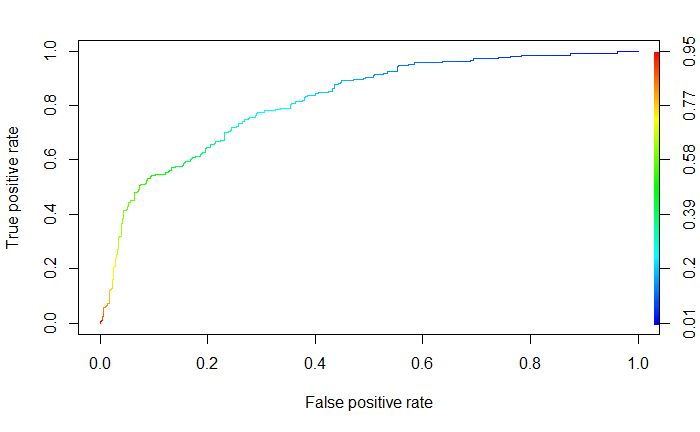

```r
train_pred<-predict(mod3,newdata = credit_train,type='response')
library(ROCR)
P_train<-prediction(train_pred,credit_train$bad_credit)
perf<-performance(P_train,'tpr','fpr')
plot(perf,colorize=T)
```

```r
performance(P_train,'auc')@y.values
```

```
[[1]]
[1] 0.8176482
```

```r
train_pred<-ifelse(train_pred>0.25,1,0)
table(train_pred,credit_train$bad_credit)
```

```
train_pred  No Yes
         0 323  44
         1 167 166
```

```r
table(train_pred)
```

```
train_pred
  0   1
367 333
```

```r
train_pred<-factor(train_pred, levels = c(0, 1), labels = c('No','Yes'))
levels(train_pred)
```

```
[1] "No"  "Yes"
```

```r
as.numeric(train_pred)
```

[output not shown]

```r
str(train_pred)
```

```
 Factor w/ 2 levels "No","Yes": 1 2 1 2 2 1 1 1 2 2 ...
 - attr(*, "names")= chr [1:700] "1" "2" "3" "5" ...
```

```r
accuracy(actual = credit_train$bad_credit,predicted = train_pred)
```

```
[1] 0.6985714
```

```r
confusionMatrix(train_pred,credit_train$bad_credit,positive = 'Yes')
```

```
Confusion Matrix and Statistics

          Reference
Prediction  No Yes
       No  323  44
       Yes 167 166

               Accuracy : 0.6986
                 95% CI : (0.6631, 0.7324)
    No Information Rate : 0.7
    P-Value [Acc > NIR] : 0.5514

                  Kappa : 0.3852
 Mcnemar's Test P-Value : <2e-16

            Sensitivity : 0.7905
            Specificity : 0.6592
         Pos Pred Value : 0.4985
         Neg Pred Value : 0.8801
             Prevalence : 0.3000
         Detection Rate : 0.2371
   Detection Prevalence : 0.4757
      Balanced Accuracy : 0.7248

       'Positive' Class : Yes
```

Let’s eventually test our model

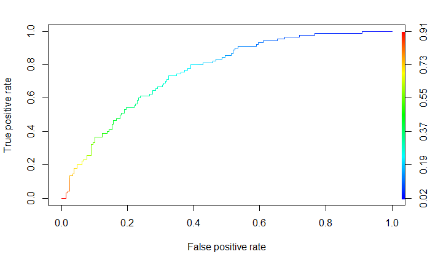

```r
pred_test<-predict(mod3,newdata = credit_test,type='response')
library(ROCR)
P_test<-prediction(pred_test,credit_test$bad_credit)
perf<-performance(P_test,'tpr','fpr')
plot(perf,colorize=T)
```

```r
performance(P_test,'auc')@y.values
```

```
[[1]]
[1] 0.7586772
```

```r
pred_test<-ifelse(pred_test>0.25,1,0)
table(pred_test,credit_test$bad_credit)
```

```
pred_test  No Yes
        0 137  23
        1  73  67
```

```r
table(pred_test)
```

```
pred_test
  0   1
160 140
```

```r
pred_test<-factor(pred_test, levels = c(0, 1), labels = c('No','Yes'))
levels(pred_test)
```

```
[1] "No"  "Yes"
```

```r
as.numeric(pred_test)
```

[output not shown]

```r
str(pred_test)
```

```
 Factor w/ 2 levels "No","Yes": 2 1 2 1 2 2 2 2 1 2 ...
 - attr(*, "names")= chr [1:300] "4" "13" "16" "29" ...
```

```r
accuracy(actual = credit_test$bad_credit,predicted = pred_test)
```

```
[1] 0.68
```

```r
confusionMatrix(pred_test,credit_test$bad_credit,positive = 'Yes')
```

```
Confusion Matrix and Statistics

          Reference
Prediction  No Yes
       No  137  23
       Yes  73  67

               Accuracy : 0.68
                 95% CI : (0.624, 0.7324)
    No Information Rate : 0.7
    P-Value [Acc > NIR] : 0.7944

                  Kappa : 0.3425
 Mcnemar's Test P-Value : 5.702e-07

            Sensitivity : 0.7444
            Specificity : 0.6524
         Pos Pred Value : 0.4786
         Neg Pred Value : 0.8562
             Prevalence : 0.3000
         Detection Rate : 0.2233
   Detection Prevalence : 0.4667
      Balanced Accuracy : 0.6984

       'Positive' Class : Yes
```

As a matter of fact confusion matrix that we get in Python is different in positions so not be fooled!!!!